# r4ds_wrangle_exercises_10-11

Long Nguyen

10/2/2017

## 10.5

### 1

Tibbles print out less data than what is shown, tibble will also show type like dbl ###2 data.frame will function like autocomplete, where `df$x` will result in `df$xyz` which can select the wrong column in some case tibble is more explicit ###3 We need to use df[[var]] here because df$var will look for column called var ###4

```r
annoying <- tibble(
  `1` = 1:10,
  `2` = `1` * 2 + rnorm(length(`1`))
)
annoying$`1`
```

```
##  [1]  1  2  3  4  5  6  7  8  9 10
```

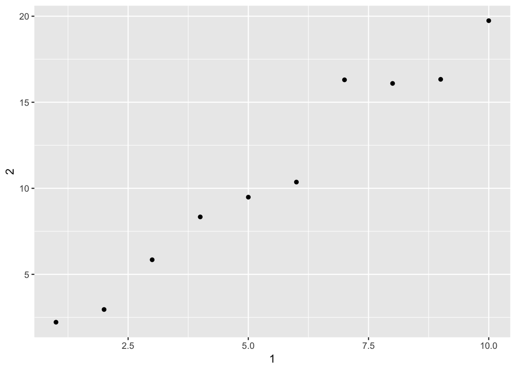

```r
ggplot(annoying, aes(x = `1`, y = `2`)) +
  geom_point()
```

```r
annoying$`3` <- annoying$`2` / annoying$`1`
annoying <- rename(annoying, one = `1`, two = `2`, three = `3`)
annoying$`three`
```

```
##  [1] 2.220525 1.479210 1.949217 2.084409 1.897013 1.726955 2.328939
##  [8] 2.011742 1.814660 1.973945
```

```r
annoying$`two`
```

```
##  [1]  2.220525  2.958419  5.847651  8.337636  9.485067 10.361731 16.302573
##  [8] 16.093937 16.331943 19.739449
```

```r
annoying$`one`
```

```
##  [1]  1  2  3  4  5  6  7  8  9 10
```

### 5

This function convert a vector to a data frame ###6 n_extra inside print.tbl_df control the extra columns ##11.2.2 ###1 read_delim() ###2 They have: file, col_names, col_types, locale, na, comment, trim_ws, skip, n_max, guess_max, progress ###3 col_positions, without this we have no idea where the column end ###4

```r
read_delim("x,y\n1,'a,b'" , ",", quote = "'")
```

```
## # A tibble: 1 x 2
##       x     y
##   <int> <chr>
## 1     1   a,b
```

### 5

```r
read_csv("a,b\n1,2,3\n4,5,6")
```

```
## # A tibble: 2 x 2
##       a     b
##   <int> <int>
## 1     1     2
## 2     4     5
```

```r
#There are only 2 column a and b but each row that follow has 3, last column is missing
read_csv("a,b,c\n1,2\n1,2,3,4")
```

```
## # A tibble: 2 x 3
##       a     b     c
##   <int> <int> <int>
## 1     1     2    NA
## 2     1     2     3
```

```r
#There are 3 column but again the column in the data doesn't match the number of column
read_csv("a,b\n\"1")
```

```
## # A tibble: 1 x 2
##       a     b
##   <int> <chr>
## 1     1  <NA>
```

```r
#There is an extra "
read_csv("a,b\n1,2\na,b")
```

```
## # A tibble: 2 x 2
##       a     b
##   <chr> <chr>
## 1     1     2
## 2     a     b
```

```r
#There is a mix of number and string in the data, the column type become string
read_csv("a;b\n1;3")
```

```
## # A tibble: 1 x 1
##   `a;b`
##   <chr>
## 1   1;3
```

```r
#Use , instead of ; for read_csv
```

## 11.3.5

### 1

I think encoding is most important because it dictate how locale is read ###2 It will throw error if decimal mark and group mark are set to the same If decimal mark is set to , the group mark is set to . If decimal mark is set to . the group mark is set to , ###3 Different place can have different date/time format, these options tell use how to parse them ###4 ###5 read_csv2 use ; instead of , ###6 UTF-8 seems to be the current standard For Asia, Japanese and Chinese has their own script. Vietnamese have ISO standard ###7

```r
d1 <- "January 1, 2010"
parse_date(d1, "%B %d, %Y")
```

```
## [1] "2010-01-01"
```

```r
d2 <- "2015-Mar-07"
parse_date(d2, "%Y-%b-%D")
```

```
## [1] "2015-07-01"
```

```r
d3 <- "06-Jun-2017"
parse_date(d3, "%D-%b-%Y")
```

```
## [1] "2017-06-01"
```

```r
d4 <- c("August 19 (2015)", "July 1 (2015)")
parse_date(d4, "%B %d (%Y)")
```

```
## [1] "2015-08-19" "2015-07-01"
```

```r
d5 <- "12/30/14" # Dec 30, 2014
parse_date(d5, "%m/%d/%y")
```

```
## [1] "2014-12-30"
```

```r
t1 <- "1705"
parse_time(t1, "%H%M")
```

```
## 17:05:00
```

```r
t2 <- "11:15:10.12 PM"
parse_time(t2)
```

```
## 23:15:10
```